# Getting, Plotting, and Saving Soil Series Extent Data from SoilWeb

2015-12-10  
Dylan Beaudette

### Introduction

This document demonstrates how to use the [soilDB](https://r-forge.r-project.org/scm/viewvc.php/*checkout*/docs/soilDB/soilDB-Intro.html?root=aqp) package to access detailed soil series extent maps via SoilWeb. These maps can be directly displayed in **R**, overlayed on Google Maps, or saved as local files (e.g. shapefiles). Data returned from SoilWeb represent bounding-boxes that enclose SSURGO polygons associated with map units containing the search criteria. Bounding-boxes are snapped to 0.01 degree precision in order to reduce processing time and file size. Note that these files are cached server-side after the first request, and the cache is purged when SoilWeb is periodically synced to the official data.

### Installation

With a recent version of R, it should be possible to get all of the packages that this tutorial depends on via:

```r
# run these commands in the R console
install.packages('soilDB', dep=TRUE) # stable version from CRAN + dependencies
install.packages('soilDB', repos="http://R-Forge.R-project.org", type="source") # most recent copy from r-forge
install.packages('dismo', dep=TRUE)
install.packages('RColorBrewer', dep=TRUE)
install.packages('maps', dep=TRUE)
```

### Examples

**Illustrate the extent of SSURGO map units associated with the Amador series.**

```r
# load required libraries
library(soilDB)
library(rgdal)
library(dismo)
library(maps)
library(RColorBrewer)
```

```r
# plot map
seriesExtentAsGmap('amador')
```

[output not shown]

**Illustrate the extent of SSURGO map units associated with several soil series from MLRA 17 and 18.**

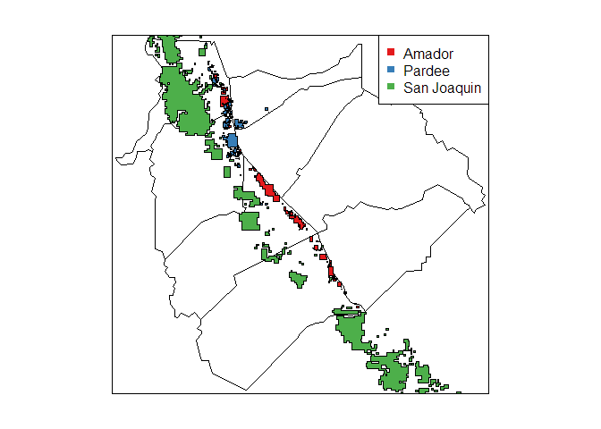

```r
# define some nice colors
cols <- brewer.pal('Set1', n=3)

# get the spatial extent of select series
amador <- seriesExtent('amador')
pardee <- seriesExtent('pardee')
san.joaquin <- seriesExtent('san joaquin', timeout=120)

# plot the results:
# set figure margins to 0
par(mar=c(0,0,0,0))

# plot select counties from California
map(database='county', regions='california,calaveras|tuolumne|amador|san joaquin|stanislaus|merced|mariposa|sacramento')

# add each soil series extent object
plot(amador, col=cols[1], add=TRUE)
plot(pardee, col=cols[2], add=TRUE)
plot(san.joaquin, col=cols[3], add=TRUE)

# add a neatline around the map
box()

# make a simple legend
legend('topright', col=cols, pch=15, legend=c('Amador','Pardee','San Joaquin'))
```

**Investigate the structure of soil series extent data.**

```r
# internal structure / class
str(amador, 2)
```

```
## Formal class 'SpatialPolygonsDataFrame' [package "sp"] with 5 slots
##   ..@ data       :'data.frame':  1 obs. of  4 variables:
##   ..@ polygons   :List of 1
##   ..@ plotOrder  : int 1
##   ..@ bbox       : num [1:2, 1:2] -121.2 37.2 -120.1 38.6
##   .. ..- attr(*, "dimnames")=List of 2
##   ..@ proj4string:Formal class 'CRS' [package "sp"] with 1 slot
```

```r
# coordinate reference system in PROJ4 notation
proj4string(amador)
```

```
## [1] "+proj=longlat +datum=WGS84 +no_defs +ellps=WGS84 +towgs84=0,0,0"
```

```r
# extract acreage, details: http://casoilresource.lawr.ucdavis.edu/see/
amador$acres
```

```
## [1] 23542
```

```r
pardee$acres
```

```
## [1] 19310
```

```r
san.joaquin$acres
```

```
## [1] 432938
```

**Save soil series extent data in multiple formats.**

```r
# save using the coordinate reference system associated with this object (GCS WGS84)
writeOGR(amador, dsn='.', layer='amador-extent', driver='ESRI Shapefile')

# save as KML for use in Google Earth
writeOGR(amador, dsn='amador-extent.kml', layer='amador', driver='KML')

# project to UTM zone 10 NAD83 and save
amador.utm <- spTransform(amador, CRS('+proj=utm +zone=10 +datum=NAD83'))
writeOGR(amador.utm, dsn='.', layer='amador-extent-utm', driver='ESRI Shapefile')
```

This document is based on `aqp` version 1.9.2 and `soilDB` version 1.6.6.